# Practical Machine Learning Final Project

J. Hoffmann

**Background**  
Using devices such as Jawbone Up, Nike FuelBand, and Fitbit it is now possible to collect a large amount of data about personal activity relatively inexpensively. These type of devices are part of the quantified self movement - a group of enthusiasts who take measurements about themselves. One thing that people do regularly is quantify how much of a particular activity they do, but they rarely quantify how well they do it. This project uses data from accelerometers on the belt, forearm, arm, and dumbbell of six participants. They were asked perform barbell lifts correctly and incorrectly in five different ways (Ugilino et al., 2012):

**Project Goal**  
The goal of this project is to predict the manner in which the participants did the exercises. The variable “classe” provides the outcome variable in the training set. Several of the other variables serve as predictors of this outcome. A key goal is to determine whether a model can successfully differentiate between doing the exercise correctly or incorrectly; thus, one might be particularly interested in successfully predicting Class A.

**Report**  
This report provides the steps used to predict the outcome “classe.” It consists of the following:

- A. Data input and cleaning stage
- B. Data set up for cross-validation
- C. The expected out of sample error, and
- D. Why certain choices were made

**STEP A: DATA INPUT & CLEANING**  
*load libraries*

```r
library(caret)
library(randomForest)
```

```r
library(e1071)
library(ggplot2)
library(AppliedPredictiveModeling)
library(gbm)
```

*Read in training set data*

```r
pml.train <- read.csv("pml-training.csv", na.strings = c("", "NA","#DIV/0!"))
```

*Read in testing set data*

```r
pml.test <- read.csv("pml-testing.csv", na.strings = c("", "NA","#DIV/0!"))
```

*Eliminate missing values and variables with all missing or that are near zero or zero variance:*

*Training data set*

```r
NAs = apply(pml.train,2,function(x) {sum(is.na(x))})
pml.train = pml.train[,which(NAs == 0)]
pml.train.new = pml.train[,8:60]
nzv = nearZeroVar(pml.train.new,saveMetrics=TRUE)
pml.train.new = pml.train.new[,nzv$nzv==FALSE]
```

*Test data set*

```r
NAs = apply(pml.test,2,function(x) {sum(is.na(x))})
pml.test = pml.test[,which(NAs == 0)]
pml.test.new = pml.test[,8:60]
nzv = nearZeroVar(pml.test.new,saveMetrics=TRUE)
pml.test.new = pml.test.new[,nzv$nzv==FALSE]
```

**STEP B: CROSS-VALIDATION & ESTIMATION OF THE RANDOM FOREST MODEL**  
The randomForest procedure in R uses cross-validation internally (Liaw, 2015), so it is used to estimate the model with the training data. The following R code utilized:

```r
set.seed(995512)
classe.RF <-  randomForest(classe ~ ., data=pml.train.new, importance=TRUE)
classe.RF
```

```
##
## Call:
##  randomForest(formula = classe ~ ., data = pml.train.new, importance = TRUE)
##                Type of random forest: classification
##                      Number of trees: 500
## No. of variables tried at each split: 7
##
##         OOB estimate of  error rate: 0.28%
## Confusion matrix:
##      A    B    C    D    E  class.error
## A 5578    2    0    0    0 0.0003584229
## B   10 3783    4    0    0 0.0036871214
## C    0   12 3410    0    0 0.0035067212
## D    0    0   19 3195    2 0.0065298507
## E    0    0    1    5 3601 0.0016634322
```

**STEP C: EXPECTED OUT-OF-SAMPLE ERROR**  
According to the results of the random forest model out-of-bag (OOB) estimate, the error rate is expected to be quite small: 0.28%, with accuracy slightly greater than 99%. Assuming we wish to predict outcome A (proper execution of exercises) accurately, its expected out-of-bag error rate is 0.04%.

**STEP C1: Assessing the Number of Predictors**  
The originator of the random forest model claimed that it could not suffer from overfitting (Breiman, 2001). Nevertheless, the randomForest library in R offers an option for feature selection using cross-validation (*rfcv*) (see Liaw, 2015). This is used next to see if a certain number of covariates are particularly useful for classification.

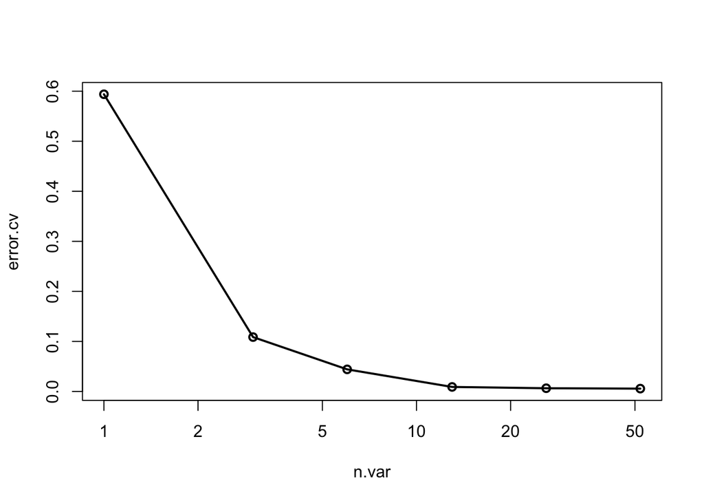

```r
cv.train <- rfcv(pml.train.new[,1:52], pml.train.new$classe, cv.fold=3)
with(cv.train, plot(n.var, error.cv, log="x", type="o", lwd=2))
```

```r
cv.train$error.cv
```

```
##          52          26          13           6           3           1
## 0.005707879 0.006472327 0.009071450 0.044185098 0.108653552 0.593874223
```

```r
importance(classe.RF)
```

```
##                             A        B        C        D        E
## roll_belt            40.46947 50.78105 48.96801 48.48870 45.63879
## pitch_belt           32.79421 53.07062 40.48563 34.20789 32.77735
## yaw_belt             47.30029 45.91989 42.49243 45.83903 31.06694
## total_accel_belt     13.66546 18.36556 14.27275 14.89053 15.65476
## gyros_belt_x         18.18287 18.63039 21.27161 13.87945 19.24770
## gyros_belt_y         11.96590 16.57249 15.51889 15.82051 17.56803
## gyros_belt_z         23.55938 29.40339 27.96771 23.63334 28.88349
## accel_belt_x         13.77657 19.78327 18.76710 15.88438 15.94645
## accel_belt_y         12.80025 16.73338 13.53651 15.87932 14.71750
## accel_belt_z         19.81295 22.49413 25.01995 21.26604 20.07246
## magnet_belt_x        19.31804 29.43282 27.17895 22.34394 27.20319
## magnet_belt_y        22.43154 27.49087 27.13854 26.04263 24.26148
## magnet_belt_z        22.87367 26.60598 24.76946 27.84403 23.92378
## roll_arm             22.57566 34.19842 28.53993 31.16656 24.87951
## pitch_arm            18.21160 24.94743 23.36963 21.51448 18.93648
## yaw_arm              24.08959 27.39572 25.78782 27.80563 20.27637
## total_accel_arm      11.34104 26.63305 21.90442 20.71723 22.32213
## gyros_arm_x          17.99823 28.45878 24.65883 25.35120 23.26576
## gyros_arm_y          22.58454 31.00921 25.96596 27.57929 24.46385
## gyros_arm_z          12.46889 18.02589 17.25606 15.60209 13.32784
## accel_arm_x          16.82152 19.29351 20.21277 22.77567 16.21942
## accel_arm_y          19.10090 25.04621 19.26956 21.37984 18.68401
## accel_arm_z          13.61943 23.86142 23.75381 24.35653 19.73189
## magnet_arm_x         17.38430 16.62861 19.67363 18.32626 15.40207
## magnet_arm_y         14.46014 18.52902 20.13313 22.40850 14.91535
## magnet_arm_z         22.45702 26.95068 26.46600 21.60918 20.19637
## roll_dumbbell        25.42580 28.80883 28.03335 29.70359 26.86988
## pitch_dumbbell       11.54935 18.69907 16.25569 13.80043 14.34362
## yaw_dumbbell         17.43542 26.08101 24.86456 22.67427 23.98956
## total_accel_dumbbell 21.00612 25.39254 21.36151 22.62756 25.43530
## gyros_dumbbell_x     21.56811 27.38217 23.89964 22.26974 21.95173
## gyros_dumbbell_y     22.55287 24.10369 30.63790 22.69642 20.16814
## gyros_dumbbell_z     20.12405 25.37788 22.25882 20.86414 18.95777
## accel_dumbbell_x     18.42654 24.89956 21.76393 20.24662 21.75923
## accel_dumbbell_y     26.51692 28.83585 29.67878 28.44717 27.18674
## accel_dumbbell_z     23.66791 28.70152 26.70994 27.77252 29.68746
## magnet_dumbbell_x    24.74032 27.70980 31.39348 27.21673 24.12551
## magnet_dumbbell_y    34.91823 39.27363 48.12901 36.79529 33.90749
## magnet_dumbbell_z    45.78156 40.34730 50.42424 37.65110 35.76811
```

[output cut: 51 more lines]

```
## magnet_dumbbell_y                44.51592        680.10894
## magnet_dumbbell_z                51.69876        766.14193
## roll_forearm                     31.14367        602.06332
## pitch_forearm                    42.76151        794.93829
## yaw_forearm                      31.79241        175.41026
## total_accel_forearm              28.49773        112.87225
## gyros_forearm_x                  32.94762         72.59396
## gyros_forearm_y                  31.49717        122.13398
## gyros_forearm_z                  37.43397         79.77238
## accel_forearm_x                  27.40670        321.31762
## accel_forearm_y                  31.22206        139.40438
## accel_forearm_z                  28.87923        237.43306
## magnet_forearm_x                 21.31771        221.38971
## magnet_forearm_y                 29.72339        222.60481
## magnet_forearm_z                 36.55350        286.47942
```

The graph suggests that the number of predictors could be reduced substantially with little sacrifice to errors in classification. In particular, examining the expected error rate (*error.cv*) suggests that the error is reduced to about 0.01 with a subset of 13 predictors. Moreover, the importance table suggests that there are particular subsets of variables that should be examined. For example, assuming one’s goal is to build a parsimonious prediction model that will assist those wishing to understand the correct execution of the exercises, it might be wise to explore a few subsets of predictors.

**Test of predictions in the test data set**  
The following was used to predict the outcome in the test data set.

```r
predict.test <- predict(classe.RF, pml.test.new)
predict.test
```

```
##  1  2  3  4  5  6  7  8  9 10 11 12 13 14 15 16 17 18 19 20
##  B  A  B  A  A  E  D  B  A  A  B  C  B  A  E  E  A  B  B  B
## Levels: A B C D E
```

**STEP D: WHY CERTAIN CHOICES WERE MADE**  
Since accuracy seems to be the main goal in this class and in this assignment, presumably over a conceptual model that might dictate the “classe” outcome, it made sense to use a random forest model. As is well known, random forest models place a premium on high predictability, even at the expense of understanding the specific effects of covariates or interaction patterns among sets of covariates. Moreover, the random forest library in R provides some useful features, such as cross-validation built into the algorithm and direct out-of-bag estimates of the error and specific classification rates.

Another option that was considered for this project was to use a boosting algorithm - in particular the generalized boosted regression model (*gbm*) - which has been shown empirically across many studies to provide a high level of accuracy (Elith et al., 2008). However, given the high degree of accuracy manifest from the random forest model, it seemed futile to use a gbm model (the gbm model took an inordinate amount of time to converge).

**References**

Breiman, L. (2001). Random forests. *Machine Learning* 45(1), 5-32.

Elith, J., Leathwick, J. R., & Hastie, T. (2008). A working guide to boosted regression trees. *Journal of Animal Ecology*, 77(4), 802-813.

Liaw, A. (2015). *Package ‘randomForest.’* Retrieved from https://cran.r-project.org/web/packages/randomForest/randomForest.pdf, July 15, 2015.

Ugulino, W., Cardador, D., Vega, K., Velloso, E., Milidiu, R., & Fuks, H. (2012). Wearable computing: Accelerometers’ data classification of body postures and movements. *Proceedings of 21<sup>st</sup> Brazilian Symposium on Artificial Intelligence. Advances in Artificial Intelligence - SBIA 2012*. In: *Lecture Notes in Computer Science*, pp. 52-61. Curitiba, PR: Springer.